# Análisis de texto con R (Bag of Words)

Librerías a utilizar:

```r
library(gutenbergr)
library(tidytext)
library(wordcloud)
library(dplyr)
library(ggplot2)
```

### Alice’s Adventures in Wonderland (Lewis Carrol)

Usamos la función gutenberg_download del paquete `gutenbergr` para extraer el texto a analizar. Pasamos como parámetro el id del libro. Para este primer ejemplo hemos elegido *Alice’s Adventures in Wonderland*, de Lewis Carrol:

```r
alice <- gutenberg_download(11)
```

```
## Determining mirror for Project Gutenberg from http://www.gutenberg.org/robot/harvest
```

```
## Using mirror http://aleph.gutenberg.org
```

```r
alice
```

```
## # A tibble: 3,339 x 2
##    gutenberg_id text
##           <int> <chr>
##  1           11 "ALICE'S ADVENTURES IN WONDERLAND"
##  2           11 ""
##  3           11 "Lewis Carroll"
##  4           11 ""
##  5           11 "THE MILLENNIUM FULCRUM EDITION 3.0"
##  6           11 ""
##  7           11 ""
##  8           11 ""
##  9           11 ""
## 10           11 "CHAPTER I. Down the Rabbit-Hole"
## # ... with 3,329 more rows
```

Tenemos el texto en un formato similar al del libro impreso, que no es lo óptimo para nuestro análisis.

Un *token* es una unidad de texto con significado, comunmente un palabra.

En nuestro caso, buscamos estructurar la información teniendo una palabra por fila. Para esto, usamos la función `unnest_tokens()` del paquete `tidytext`.

```r
tidy_alice <- unnest_tokens(alice,word,text)
tidy_alice
```

```
## # A tibble: 26,694 x 2
##    gutenberg_id word
##           <int> <chr>
##  1           11 alice's
##  2           11 adventures
##  3           11 in
##  4           11 wonderland
##  5           11 lewis
##  6           11 carroll
##  7           11 the
##  8           11 millennium
##  9           11 fulcrum
## 10           11 edition
## # ... with 26,684 more rows
```

```r
dim(tidy_alice)
```

```
## [1] 26694     2
```

Ahora podemos obtener la frecuencia de cada palabra en el texto:

```r
#Usamos dplyr's count()
tidy_alice <- count(tidy_alice,word,sort=TRUE)
tidy_alice
```

```
## # A tibble: 2,634 x 2
##    word      n
##    <chr> <int>
##  1 the    1644
##  2 and     872
##  3 to      729
##  4 a       632
##  5 she     541
##  6 it      530
##  7 of      514
##  8 said    462
##  9 i       408
## 10 alice   386
## # ... with 2,624 more rows
```

```r
dim(tidy_alice)
```

```
## [1] 2634    2
```

Notamos que las palabras más frecuentes en el texto no nos dan información relevante acerca del mismo.

Removemos estas palabras vacías con un anti join con el data frame stop_words

```r
tidy_alice <- anti_join(tidy_alice,stop_words)
tidy_alice
```

```
## # A tibble: 2,165 x 2
##    word        n
##    <chr>   <int>
##  1 alice     386
##  2 time       71
##  3 queen      68
##  4 king       61
##  5 turtle     57
##  6 mock       56
##  7 gryphon    55
##  8 hatter     55
##  9 head       49
## 10 voice      48
## # ... with 2,155 more rows
```

```r
dim(tidy_alice)
```

```
## [1] 2165    2
```

Esta vez nuestro data frame refleja mucho mejor el contenido del libro, como podemos visualizar en la siguiente gráfica, en la que mostramos las palabras con frecuencia mayor a 30

```r
tidy_alice_g <- filter(tidy_alice,n>30)
tidy_alice_g <- mutate(tidy_alice_g,word = reorder(word, n))
tidy_alice_g
```

```
## # A tibble: 21 x 2
##    word        n
##    <fct>   <int>
##  1 alice     386
##  2 time       71
##  3 queen      68
##  4 king       61
##  5 turtle     57
##  6 mock       56
##  7 gryphon    55
##  8 hatter     55
##  9 head       49
## 10 voice      48
## # ... with 11 more rows
```

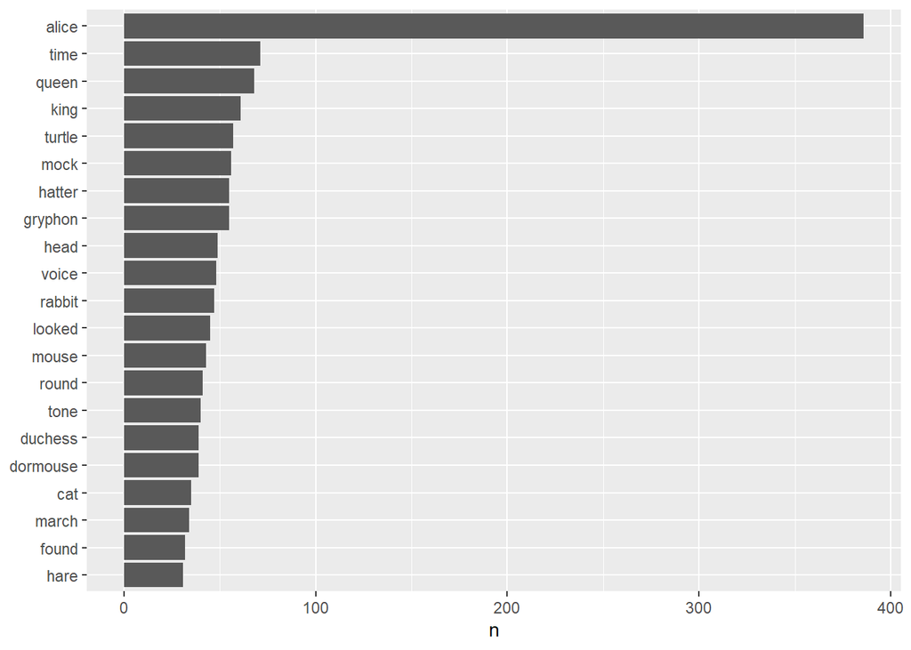

```r
ggplot(tidy_alice_g,aes(word,n))+
  geom_col()+
  xlab(NULL)+
  coord_flip()
```

Otra forma de visualizarlo:

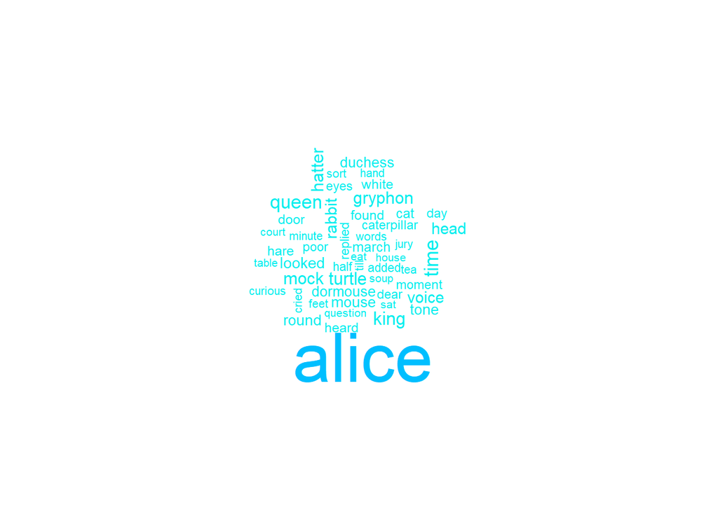

```r
wordcloud(tidy_alice$word, tidy_alice$n, max.words=50, colors = c("cyan2","deepskyblue"))
```

Sigamos estos pasos para otro par de libros, usando el operador pipe (%>%)

### Through the Looking-Glass (Lewis Carrol)

```r
looking_glass <- gutenberg_download(12)
tidy_looking_glass <- looking_glass %>%
  unnest_tokens(word,text) %>%
  anti_join(stop_words) %>%
  count(word,sort=TRUE)
tidy_looking_glass
```

```
## # A tibble: 2,359 x 2
##    word       n
##    <chr>  <int>
##  1 alice    434
##  2 queen    179
##  3 time      70
##  4 red       69
##  5 white     67
##  6 head      63
##  7 king      61
##  8 knight    57
##  9 cried     56
## 10 looked    55
## # ... with 2,349 more rows
```

```r
dim(tidy_looking_glass)
```

```
## [1] 2359    2
```

### The Adventures of Sherlock Holmes (Arthur Conan Doyle)

```r
sherlock <- gutenberg_download(1661)
tidy_sherlock <- sherlock %>%
  unnest_tokens(word,text) %>%
  anti_join(stop_words) %>%
  count(word,sort=TRUE)
tidy_sherlock
```

```
## # A tibble: 7,440 x 2
##    word       n
##    <chr>  <int>
##  1 holmes   462
##  2 time     151
##  3 door     144
##  4 matter   125
##  5 house    123
##  6 hand     120
##  7 night    114
##  8 heard    113
##  9 found    108
## 10 day      106
## # ... with 7,430 more rows
```

```r
dim(tidy_sherlock)
```

```
## [1] 7440    2
```

Grafiquemos las palabras más frecuentes de estos dos nuevos libros

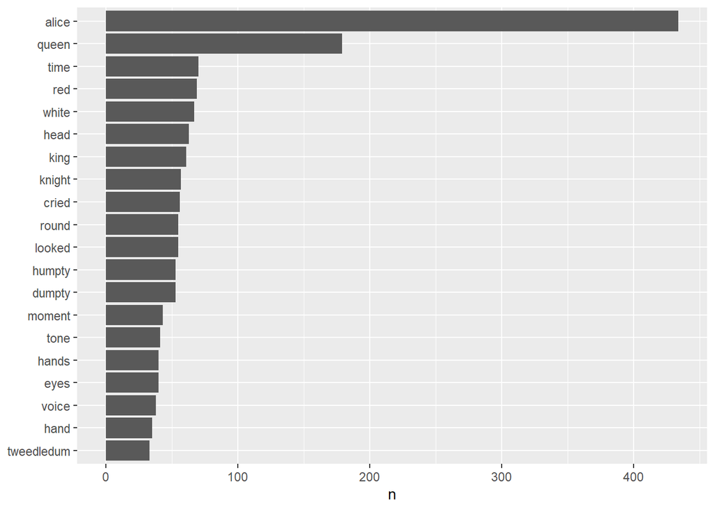

```r
tidy_glass_g <- filter(tidy_looking_glass,n>30)
tidy_glass_g <- mutate(tidy_glass_g,word = reorder(word, n))
ggplot(tidy_glass_g,aes(word,n))+
  geom_col()+
  xlab(NULL)+
  coord_flip()
```

```r
tidy_sherlock_g <- head(tidy_sherlock,30)
tidy_sherlock_g <- mutate(tidy_sherlock_g,word = reorder(word, n))
tidy_sherlock_g
```

```
## # A tibble: 30 x 2
##    word       n
##    <fct>  <int>
##  1 holmes   462
##  2 time     151
##  3 door     144
##  4 matter   125
##  5 house    123
##  6 hand     120
##  7 night    114
##  8 heard    113
##  9 found    108
## 10 day      106
## # ... with 20 more rows
```

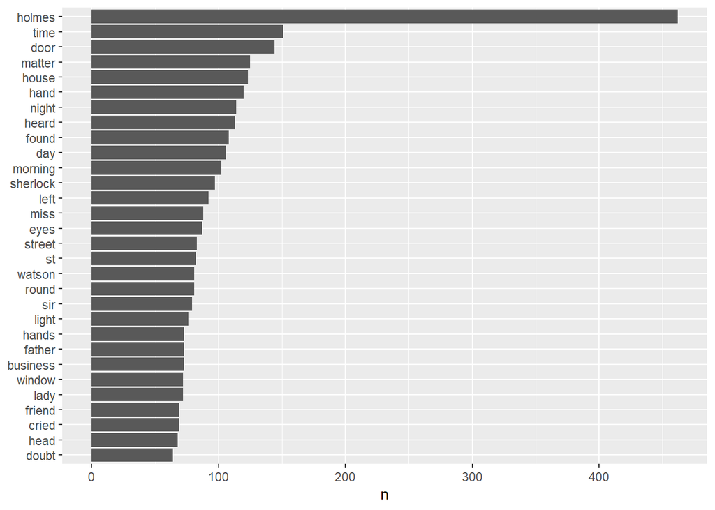

```r
ggplot(tidy_sherlock_g,aes(word,n))+
  geom_col()+
  xlab(NULL)+
  coord_flip()
```

O bien, con wordcloud:

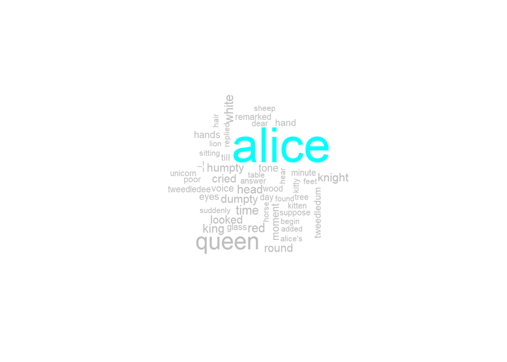

```r
wordcloud(tidy_looking_glass$word, tidy_looking_glass$n, max.words=50, colors = c("gray","cyan"))
```

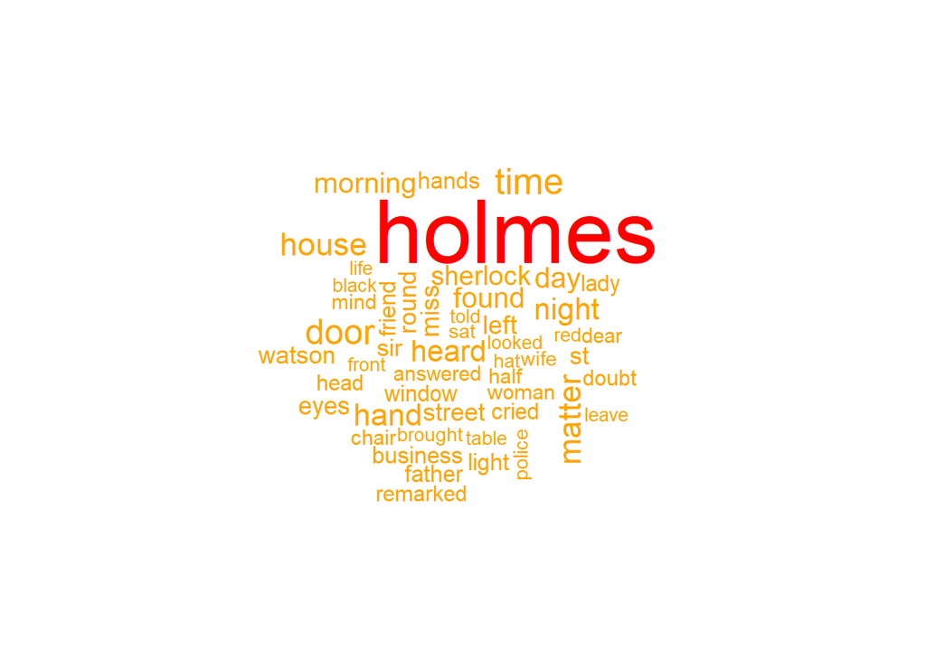

```r
wordcloud(tidy_sherlock$word, tidy_sherlock$n, max.words=50, colors = c("orange","red"))
```

Calculamos las frecuencias relativas

```r
tidy_alice_f <- mutate(tidy_alice, proportion = n/sum(n))
tidy_looking_glass_f <- mutate(tidy_looking_glass,proportion = n/sum(n))
tidy_sherlock_f <- mutate(tidy_sherlock,proportion = n/sum(n))
```

### Comparación final

Comparemos los tres textos, combinándolos en un solo dataframe.

```r
frecuencias <- bind_rows(mutate(tidy_alice_f, book ="Alice"),mutate(tidy_looking_glass_f,book="Through the Looking-Glass"),                         mutate(tidy_sherlock_f, book = "Sherlock Holmes")) %>%
  select(-n)
  frecuencias
```

```
## # A tibble: 11,964 x 3
##    word    proportion book
##    <chr>        <dbl> <chr>
##  1 alice      0.0507  Alice
##  2 time       0.00932 Alice
##  3 queen      0.00893 Alice
##  4 king       0.00801 Alice
##  5 turtle     0.00748 Alice
##  6 mock       0.00735 Alice
##  7 gryphon    0.00722 Alice
##  8 hatter     0.00722 Alice
##  9 head       0.00643 Alice
## 10 voice      0.00630 Alice
## # ... with 11,954 more rows
```

Usamos `spread` y `gather` del paquete `tidyr`

```r
library(tidyr)
```

```r
frecuencias_s <- spread(frecuencias, book, proportion)
frecuencias_s
```

```
## # A tibble: 8,855 x 4
##    word      Alice `Sherlock Holmes` `Through the Looking-Glass`
##    <chr>     <dbl>             <dbl>                       <dbl>
##  1 ___   NA               NA                            0.000116
##  2 ____  NA               NA                            0.000116
##  3 _i_    0.000263        NA                            0.00209
##  4 1     NA                0.0000312                    0.000116
##  5 1.7   NA               NA                            0.000116
##  6 10    NA                0.0000312                   NA
##  7 100   NA                0.0000935                   NA
##  8 1000  NA                0.000249                    NA
##  9 10s   NA                0.0000623                   NA
## 10 10th  NA                0.0000312                   NA
## # ... with 8,845 more rows
```

```r
frecuencias_g <- gather(frecuencias_s,book, proportion,'Through the Looking-Glass':'Sherlock Holmes')
dim(frecuencias_g)
```

```
## [1] 17710     4
```

```r
frecuencias_g
```

```
## # A tibble: 17,710 x 4
##    word      Alice book                      proportion
##    <chr>     <dbl> <chr>                          <dbl>
##  1 ___   NA        Through the Looking-Glass   0.000116
##  2 ____  NA        Through the Looking-Glass   0.000116
##  3 _i_    0.000263 Through the Looking-Glass   0.00209
##  4 1     NA        Through the Looking-Glass   0.000116
##  5 1.7   NA        Through the Looking-Glass   0.000116
##  6 10    NA        Through the Looking-Glass  NA
##  7 100   NA        Through the Looking-Glass  NA
##  8 1000  NA        Through the Looking-Glass  NA
##  9 10s   NA        Through the Looking-Glass  NA
## 10 10th  NA        Through the Looking-Glass  NA
## # ... with 17,700 more rows
```

Eliminamos las filas vacías:

```r
frecuencias_g <- filter(frecuencias_g,!(is.na(Alice))&!(is.na(proportion)))
dim(frecuencias_g)
```

```
## [1] 2557    4
```

```r
frecuencias_g
```

```
## # A tibble: 2,557 x 4
##    word          Alice book                      proportion
##    <chr>         <dbl> <chr>                          <dbl>
##  1 _i_        0.000263 Through the Looking-Glass   0.00209
##  2 accident   0.000263 Through the Looking-Glass   0.000116
##  3 accounts   0.000131 Through the Looking-Glass   0.000116
##  4 act        0.000131 Through the Looking-Glass   0.000116
##  5 added      0.00302  Through the Looking-Glass   0.00244
##  6 addressed  0.000263 Through the Looking-Glass   0.000116
##  7 addressing 0.000131 Through the Looking-Glass   0.000349
##  8 advantage  0.000394 Through the Looking-Glass   0.000116
##  9 adventures 0.000919 Through the Looking-Glass   0.000116
## 10 advice     0.000263 Through the Looking-Glass   0.000349
## # ... with 2,547 more rows
```

Y graficamos

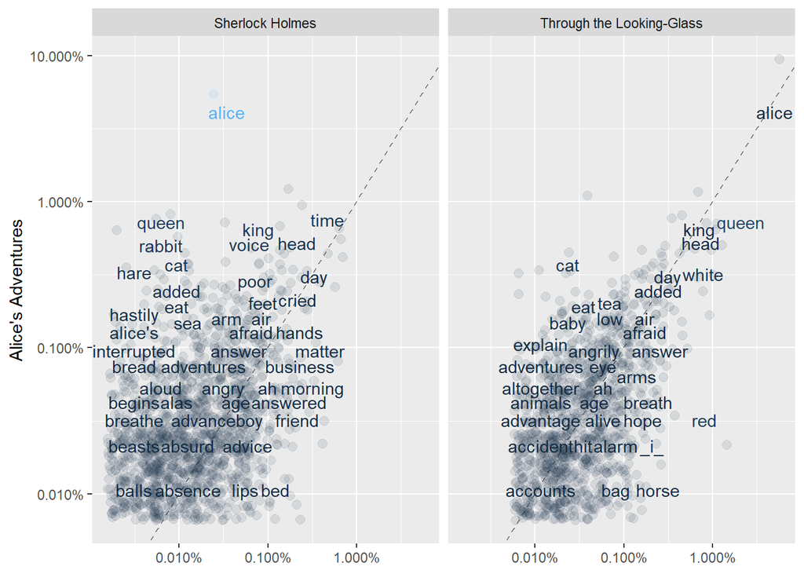

```r
library(scales)

ggplot(frecuencias_g,aes(x=proportion,y=Alice, color = abs(Alice- proportion))) +
  geom_abline(color= "gray40", lty = 2)+
  geom_jitter(alpha = 0.1, size = 2.5, width = 0.3, height = 0.3)+
  geom_text(aes(label = word), check_overlap = TRUE, vjust = 1.5) +
  scale_x_log10(labels = percent_format()) +
  scale_y_log10(labels = percent_format()) +
  facet_wrap(~book, ncol = 2) +
  theme(legend.position="none") +
  labs(y = "Alice's Adventures", x = NULL)
```

## Referencias

https://www.tidytextmining.com/tidytext.html

https://CRAN.R-project.org/package=tidytext

https://cran.r-project.org/package=dplyr

https://rsanchezs.gitbooks.io/rprogramming/content/chapter9/pipeline.html